# **Deep Dive Report**

TheDataAreClean

7th April, ’20

### **Objective**

Follow-up on initial assignment with a deep dive.

- Specific issues under Education, analyse the account heads for budget expenditure and district spending trends
- Identify some key fund flow issues and/or interesting data insights/stories

#### **Read**

Read the cleaned dataset after processing through the Data Health Report

```r
# State expenditure data
budget_exp_final <- read_csv("../data/processed/budget_exp_final.csv")

# Distirct spending data
district_spending_exp_final <- read_csv("../data/processed/district_spending_exp_final.csv")
```

#### **Clean**

Normalize the data fields across files for analysis.

```r
# Format the monetary value fields
# State Budget Expenditure
budget_exp_final$sanction <- accounting(budget_exp_final$sanction)
budget_exp_final$addition <- accounting(budget_exp_final$addition)
budget_exp_final$savings <- accounting(budget_exp_final$savings)
budget_exp_final$revised <- accounting(budget_exp_final$revised)

# District Spending  Expenditure
district_spending_exp_final$gross <- accounting(district_spending_exp_final$gross)
district_spending_exp_final$agded <- accounting(district_spending_exp_final$agded)
district_spending_exp_final$btded <- accounting(district_spending_exp_final$btded)
district_spending_exp_final$net_payment <- accounting(district_spending_exp_final$net_payment)
```

### **Sector Analysis**

Analysis of Education Department entries in the FY 2018-19 budget expenditure datasets.

```r
# Account Heads
state_exp_ed_18_19 <- budget_exp_final %>%
    filter(demand_desc == "EDUCATION" & year == "2018-19") %>%
    group_by(major_desc, sub_major_desc) %>%
    summarise(sanction = sum(sanction), revised = sum(revised)) %>%
    mutate(percent = (revised - sanction)/sanction) %>%
    arrange(desc(revised))

# Rename Fields
names(state_exp_ed_18_19) <- c("Major", "Sub Major", "Sanction", "Revised", "Percent")

# Format Fields
state_exp_ed_18_19$Percent <- formattable::percent(state_exp_ed_18_19$Percent)

# Print formatted table
formattable(state_exp_ed_18_19, list(
                                    Sanction = color_tile("coral", "tomato"),
                                    Revised = color_tile("lightgreen", "seagreen"),
                                    Percent = color_tile("paleturquoise", "turquoise")
                                    )
            )
```

| Major | Sub Major | Sanction | Revised | Percent |
| --- | --- | --- | --- | --- |
| GENERAL EDUCATION | ELEMENTARY EDUCATION | 118,728,372.66 | 98,541,261.66 | -17.00% |
| GENERAL EDUCATION | SECONDARY EDUCATION | 85,107,050.70 | 71,888,971.84 | -15.53% |
| GENERAL EDUCATION | UNIVERSITY AND HIGHER EDUCATION | 15,984,225.84 | 14,480,514.04 | -9.41% |
| CAPITAL OUTLAY ON EDUCATION S | GENERAL EDUCATION | 3,827,114.68 | 4,013,783.60 | 4.88% |
| GENERAL EDUCATION | GENERAL | 785,825.98 | 1,061,528.80 | 35.08% |
| PUBLIC WORKS | OFFICE BUILDINGS | 613,955.62 | 608,514.76 | -0.89% |
| ART AND CULTURE | NA | 183,903.24 | 306,693.64 | 66.77% |
| GENERAL EDUCATION | LANGUAGE DEVELOPMENT | 241,989.76 | 218,619.04 | -9.66% |
| LOANS FOR EDUCATION SPORTS AR | GENERAL EDUCATION | 3.62 | 72,400.00 | 1999900.00% |
| SOCIAL SECURITY AND WELFARE | SOCIAL WELFARE | 9,774.00 | 9,296.16 | -4.89% |
| GENERAL EDUCATION | ADULT EDUCATION | 724.00 | 0.00 | -100.00% |
| WELFARE OF SCHEDULED CASTES SC | WELFARE OF BACKWARD CLASSES | 36,200.00 | 0.00 | -100.00% |

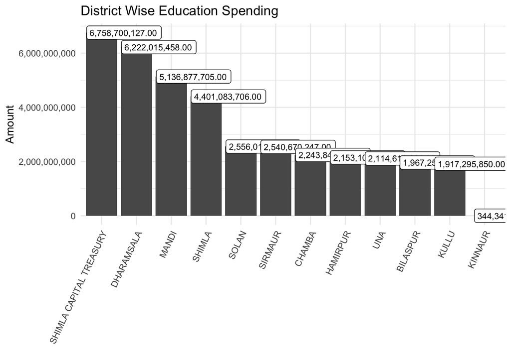

```r
# Account Heads
district_spending_exp_final %>%
    filter(demand_desc == "EDUCATION" & year == "2018-19") %>%
    group_by(district) %>%
    summarise(net_payment = sum(net_payment)) %>%
    arrange(desc(net_payment)) %>%
    mutate(district = as_factor(district)) %>%
    ggplot(aes(x = district, y = net_payment, label = net_payment)) +
        geom_bar(stat = "identity") + scale_y_continuous(labels = comma) +
        geom_label(size = 3, hjust = 0.2) +
        labs(title = "District Wise Education Spending", x = "", y = "Amount") +
        theme_minimal() + theme(axis.text.x = element_text(angle = 65, vjust = 1, hjust = 1))
```

**Findings**

- ~98% of all state education expenditure was towards General Education function.
- The top sub-sectors were Elementary Education (53.76%), Secondary Education (38.54%) & University and Higher Education (7.24%).
- Lahaul and Spiti do not have any education spending in 2018-19; even with schools present in the area.
- *Areas of Exploration*:
  1. WELFARE OF SCHEDULED CASTES SC
  2. SOCIAL SECURITY AND WELFARE
  3. LANGUAGE DEVELOPMENT
  4. ART AND CULTURE

#### **Welfare Of Scheduled Castes**

Review on the welfare funding under state expenditure FY 2018-19.

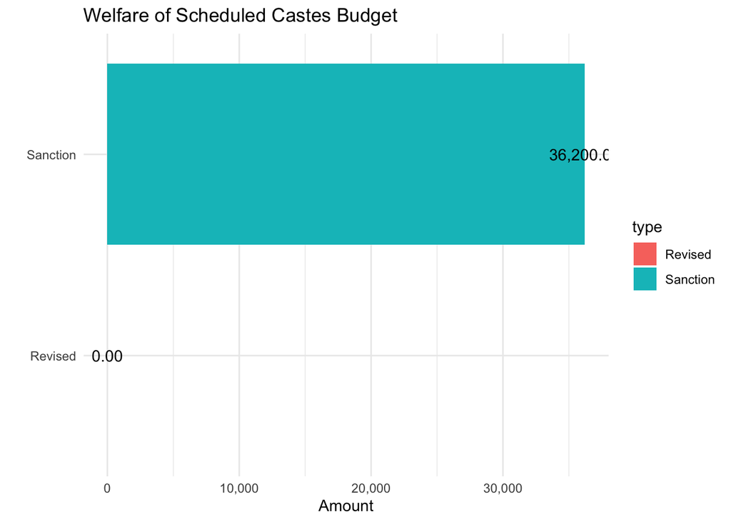

```r
# Welfare of Scheduled Castes SC
budget_exp_final %>%
    filter(demand_desc == "EDUCATION" & year == "2018-19" &
             major_desc == "WELFARE OF SCHEDULED CASTES SC") %>%
    group_by(sub_minor_desc) %>%
    summarise(Sanction = sum(sanction), Revised = sum(revised)) %>%
    gather(type, amount, -sub_minor_desc) %>%
    ggplot(aes(x = type, y = amount, fill = type, label = amount)) +
        geom_bar(stat = "identity") + scale_y_continuous(labels = comma) +
        geom_text(hjust = 0.5) +
        labs(title = "Welfare of Scheduled Castes Budget", x = "", y = "Amount") +
        theme_minimal() + coord_flip()
```

- Welfare Of Scheduled Castes SC had ₹36,200 lacs under sanctions, revised to zero later.
- The amount was allocated against Sub-Minor: SCHOLARSHIPS TO MINORITY COMMUNITIES [C00N]
- There is no district level spending under WELFARE OF SCHEDULED CASTES SC major head, confirming the findings in the state expenditure file.

```r
# Education Spending
sc_state_exp_ed <- budget_exp_final %>%
    filter(year == "2018-19") %>%
    filter(demand_desc =="SCHEDULED CASTES SUB PLAN" &
           stringr::str_detect(major_desc, pattern = "EDUC")) %>%
    group_by(demand_desc, major_desc) %>%
    summarise(sanction = sum(sanction), revised = sum(revised)) %>%
    mutate(percent = (revised - sanction)/sanction) %>%
    arrange(desc(revised))

# Format % Field
sc_state_exp_ed$percent <- formattable::percent(sc_state_exp_ed$percent)

# Rename Fields
names(sc_state_exp_ed) <- c("Demand Desc", "Major Desc", "Sanction", "Revised", "Percent")

# Print formatted table
formattable(sc_state_exp_ed,
            list(
              Sanction = color_tile("coral", "tomato"),
              Revised = color_tile("lightgreen", "seagreen"),
              Percent = color_tile("paleturquoise", "turquoise")
              )
)
```

| Demand Desc | Major Desc | Sanction | Revised | Percent |
| --- | --- | --- | --- | --- |
| SCHEDULED CASTES SUB PLAN | GENERAL EDUCATION | 14,329,770.00 | 10,883,815.98 | -24.05% |
| SCHEDULED CASTES SUB PLAN | CAPITAL OUTLAY ON EDUCATION S | 1,939,958.00 | 2,135,003.60 | 10.05% |
| SCHEDULED CASTES SUB PLAN | AGRICULTURAL RESEARCH AND EDUC | 1,522,934.00 | 1,522,934.00 | 0.00% |
| SCHEDULED CASTES SUB PLAN | TECHNICAL EDUCATION | 19,910.00 | 29,636.94 | 48.85% |

Post further exploration, it was discovered there is education spending under the SCHEDULED CASTES SUB PLAN.

#### **Social Security and Welfare**

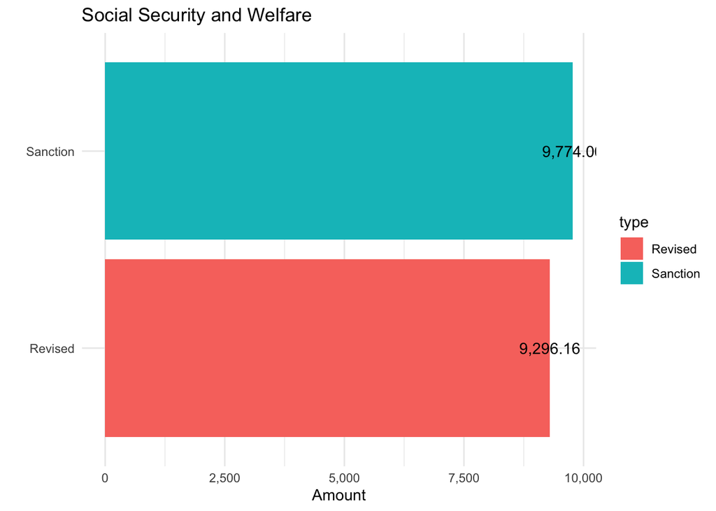

```r
# Social Security and Welfare
budget_exp_final %>%
    filter(demand_desc == "EDUCATION" & year == "2018-19" &
             major_desc == "SOCIAL SECURITY AND WELFARE") %>%
    group_by(sub_minor_desc) %>%
    summarise(Sanction = sum(sanction), Revised = sum(revised)) %>%
    gather(type, amount, -sub_minor_desc) %>%
    ggplot(aes(x = type, y = amount, fill = type, label = amount)) +
        geom_bar(stat = "identity") + scale_y_continuous(labels = comma) +
        geom_text(hjust = 0.5) +
        labs(title = "Social Security and Welfare", x = "", y = "Amount") +
        theme_minimal() + coord_flip()
```

- Social Security and Welfare had a little over ₹9,000 lacs under state budget expenditure.
- The amount was allocated against Sub-Minor: WELFARE OF HANDICAPPED CHILDREN [C00N]; 0.004% of the total education state budget.

```r
# Social Security and Welfare
welfare_dist_exp <- district_spending_exp_final %>%
    filter(demand_desc == "EDUCATION" & year == "2018-19" &
             major_desc == "SOCIAL SECURITY AND WELFARE") %>%
    group_by(district, ddo_desc) %>%
    summarise(net_payment = sum(net_payment)) %>%
    arrange(desc(net_payment))

# Rename Fields
names(welfare_dist_exp) <- c("District", "DDO", "Net Payment")

# Print formatted table
formattable(welfare_dist_exp,
            list(
                `Net Payment` = color_tile("coral", "tomato")
                )
            )
```

| District | DDO | Net Payment |
| --- | --- | --- |
| SHIMLA | GSSS PHAGLI | 588,878.00 |
| SIRMAUR | PR GSSS BOYS NAHAN | 530,473.00 |
| SHIMLA | HM GHS KRISHAN NAGAR SHIMLA | 368,857.00 |
| CHAMBA | GSSS (GIRLS) CHAMBA | 188,438.00 |
| DHARAMSALA | PR GSSS (BOYS) DHARAMSALA | 52,366.00 |

- Only 4 districts have Social Security and Welfare Spending, towards welfare of Handicapped Children.
- All the spending is towards the SOE of salaries.
- 5 DDOs from the 4 districts; which are Govt. Senior Secondary and Higher Secondary schools.

#### **Language Development**

```r
# Language Development
lang_dev <- budget_exp_final %>%
    filter(demand_desc == "EDUCATION" & year == "2018-19" &
             sub_major_desc == "LANGUAGE DEVELOPMENT") %>%
    group_by(sub_minor_desc) %>%
    summarise(sanction = sum(sanction), revised = sum(revised)) %>%
    mutate(percent = (revised - sanction)/sanction) %>%
    arrange(desc(revised))

# Format % Field
lang_dev$percent <- formattable::percent(lang_dev$percent)

# Rename Fields
names(lang_dev) <- c("Sub-Minor", "Sanction", "Revised", "Percent")

# Print formatted table
formattable(lang_dev,
            list(
              Sanction = color_tile("coral", "tomato"),
              Revised = color_tile("lightgreen", "seagreen"),
              Percent = color_tile("paleturquoise", "turquoise")
              )
)
```

| Sub-Minor | Sanction | Revised | Percent |
| --- | --- | --- | --- |
| MODERNISATION OF SANSKRIT PATHSHALAS [S00N] | 238,007.76 | 214,637.04 | -9.82% |
| G.I.A TO NON GOVT.SANSKRIT PATHSHALAS [S00N] | 3,982.00 | 3,982.00 | 0.00% |

- All the spending under language development is for Sanskrit Pathshalas.
- In 2019, Sanskrit was declared as the second official language of HP.

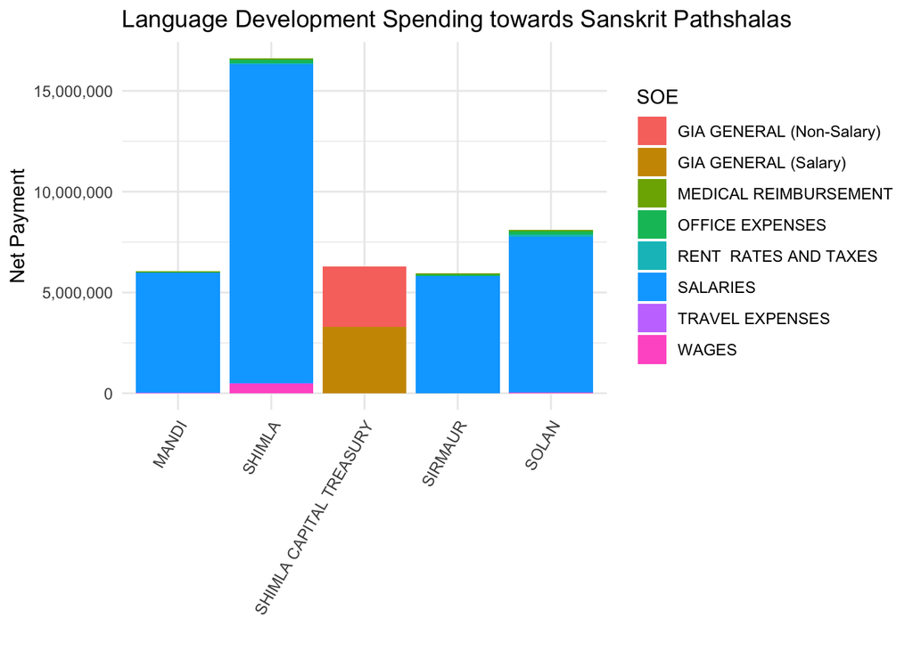

```r
# Language Development District/SOEs
district_spending_exp_final %>%
    filter(demand_desc == "EDUCATION" & year == "2018-19" &
             sub_major_desc == "LANGUAGE DEVELOPMENT") %>%
    group_by(district, soe_description) %>%
    summarise(net_payment = sum(net_payment)) %>%
    arrange(desc(net_payment)) %>%
    ggplot(aes(x = district, y = net_payment, fill = soe_description)) +
        geom_bar(stat = "identity", position = "stack") +
        scale_y_continuous(labels = comma) +
        labs(title = "Language Development Spending towards Sanskrit Pathshalas",
             x = "", y = "Net Payment") +
        scale_fill_discrete(name = "SOE") +
        theme_minimal() + theme(axis.text.x = element_text(angle = 60, vjust = 1, hjust = 1))
```

```r
# Language Development
lang_dev_dist <- district_spending_exp_final %>%
    filter(demand_desc == "EDUCATION" & year == "2018-19" &
             sub_major_desc == "LANGUAGE DEVELOPMENT") %>%
    group_by(district, ddo_desc) %>%
    summarise(net_payment = sum(net_payment))

# Rename fields
names(lang_dev_dist) <- c("District", "DDO", "Net Payment")

# Print formatted table
formattable(lang_dev_dist,
            list(
                `Net Payment` = color_tile("coral", "tomato")
                )
            )
```

| District | DDO | Net Payment |
| --- | --- | --- |
| MANDI | PR SANSKRIT COLLEGE SNR | 6,051,330.00 |
| SHIMLA | PR GOVT SANS COLLEGE KIARTOO | 5,173,790.00 |
| SHIMLA | PR NEHRU SANSKRIT COLLEGE SHIMLA | 8,194,993.00 |
| SHIMLA | PRINCIPAL GOVT SANSKRIT COLLEGE SARAIN (CHOPAL) | 112,636.00 |
| SHIMLA | PRINCIPAL GOVT SANSKRIT COLLEGE TUNGESH | 3,118,509.00 |
| SHIMLA CAPITAL TREASURY | A.O.(EDUCATION DEPTT) SHIMLA | 6,300,000.00 |
| SIRMAUR | PR SANSKRIT COLLAGE NAHAN | 5,942,635.00 |
| SOLAN | PR GOVT.SANSK.COLLEGE SOLAN | 8,116,666.00 |

- 5 districts are spending towards Language Development (Sanskrit Pathshalas); mostly on Salaries.
- Most DDOs are Sanskrit Colleges working in these district areas.

#### **Art and Culture**

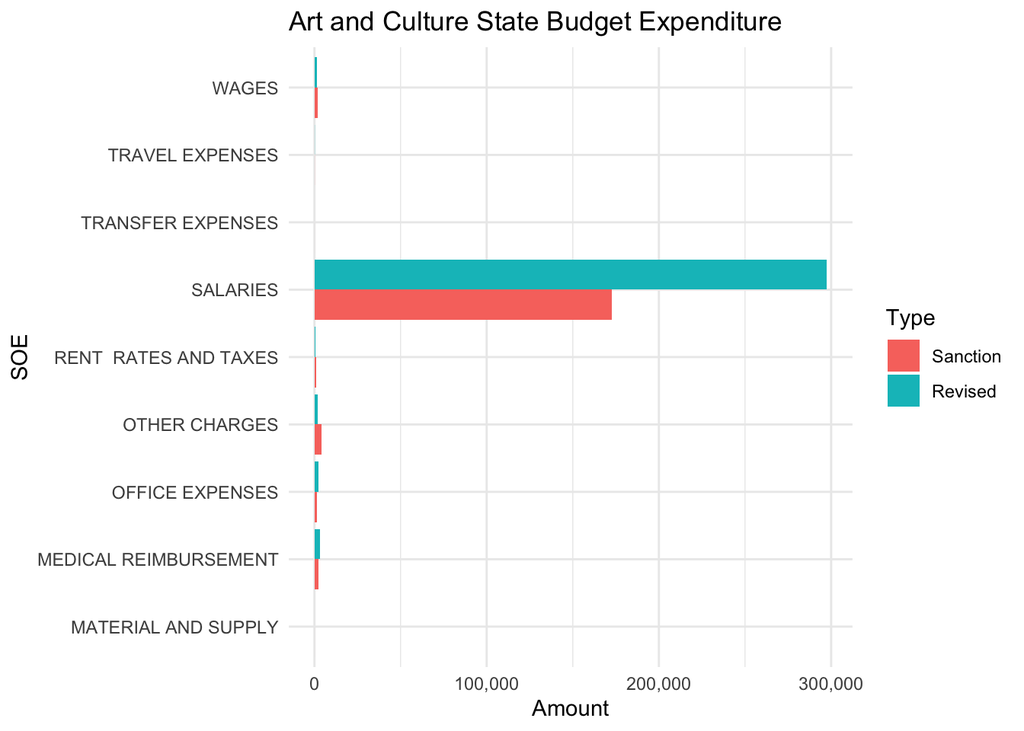

```r
# Art and culture
budget_exp_final %>%
    filter(demand_desc == "EDUCATION" & year == "2018-19" &
             major_desc == "ART AND CULTURE") %>%
    group_by(soe_description) %>%
    summarise(sanction = sum(sanction), revised = sum(revised)) %>%
    gather(type, amount, -soe_description) %>%
    mutate(type = as_factor(type)) %>%
    ggplot(aes(x = soe_description, y = amount, fill = type)) +
        geom_bar(stat = "identity", position = "dodge") +
        scale_y_continuous(labels = comma) +
        scale_fill_discrete(name = "Type", labels = c("Sanction", "Revised")) +
        labs(title = "Art and Culture State Budget Expenditure", x = "SOE", y = "Amount") +
        theme_minimal() + coord_flip()
```

All the Arts and Culture state budget expenditure was towards State and District Public Libraries, with the majority of amount going towards salaries.

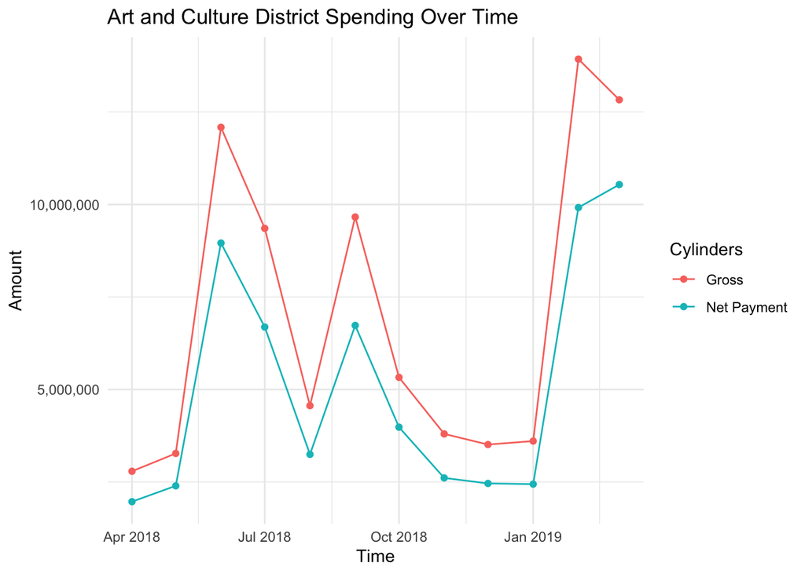

```r
# Art and culture spending over time
district_spending_exp_final %>%
    filter(demand_desc == "EDUCATION" & year == "2018-19" &
             major_desc == "ART AND CULTURE") %>%
    mutate(month = floor_date(transaction_date, unit = "month")) %>%
    group_by(month) %>%
    summarise(gross = sum(gross),
              net_payment = sum(net_payment)) %>%
    gather(type, amount, -month) %>%
    ggplot(aes(x = month, y = amount, color = type)) +
    geom_line() + geom_point() +
    scale_y_continuous(labels = comma) +
    scale_color_discrete(name = "Cylinders", labels = c("Gross", "Net Payment")) +
    labs(title = "Art and Culture District Spending Over Time", x = "Time", y = "Amount") +
    theme_minimal()
```

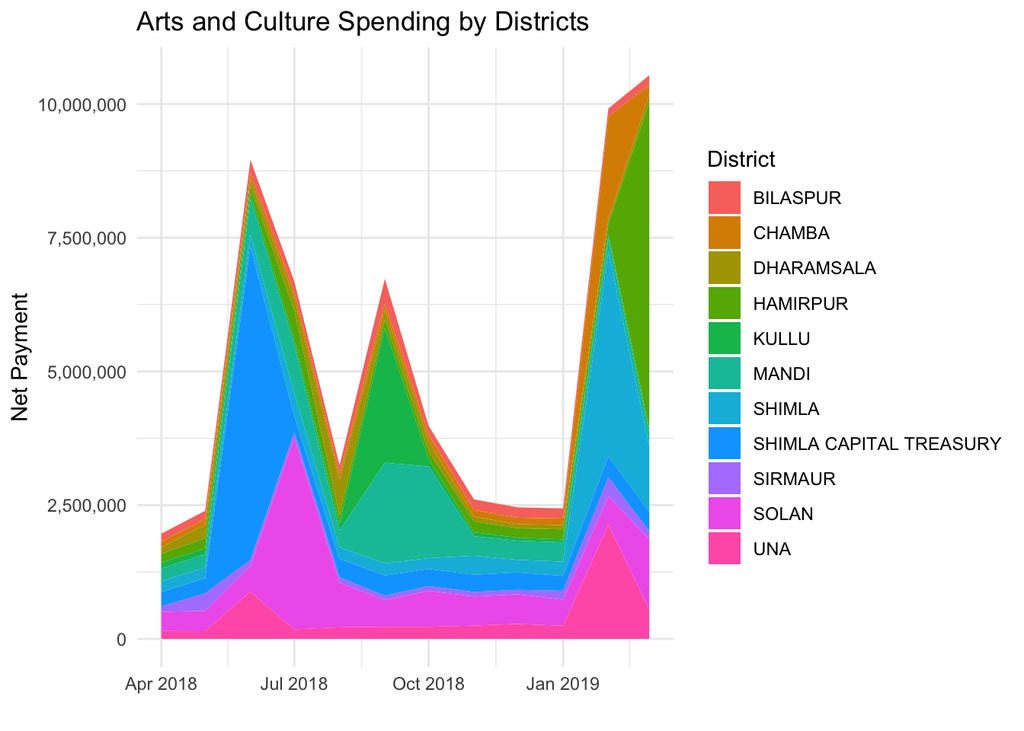

```r
# Art and culture district spending over time
district_spending_exp_final %>%
    filter(demand_desc == "EDUCATION" & year == "2018-19" &
             major_desc == "ART AND CULTURE") %>%
    mutate(month = floor_date(transaction_date, unit = "month")) %>%
    group_by(month, district) %>%
    summarise(net_payment = sum(net_payment)) %>%
    ggplot(aes(x = month, y = net_payment, fill = district)) +
    geom_area(stat = "identity", position = "stack") +
        scale_y_continuous(labels = comma) +
        labs(title = "Arts and Culture Spending by Districts",
             x = "", y = "Net Payment") +
        scale_fill_discrete(name = "District") +
        theme_minimal()
```

- District level spending peaks in Jun, ’18, Feb, ’19 and Mar, ’19
- Large spikes in spending in Shimla (Jun, ’18) and Harmirpur (Mar, ’19)

```r
# Art and culture district spending by DDO
art_ddo_dist_exp <- district_spending_exp_final %>%
    filter(demand_desc == "EDUCATION" & year == "2018-19" &
             major_desc == "ART AND CULTURE") %>%
    group_by(district, ddo_desc) %>%
    summarise(net_payment = sum(net_payment)) %>%
    arrange(desc(net_payment)) %>%
    head(10)

# Rename fields
names(art_ddo_dist_exp) <- c("District", "DDO", "Net Payment")

# Print formatted table
formattable(art_ddo_dist_exp,
            list(
                `Net Payment` = color_tile("coral", "tomato")
                )
            )
```

| District | DDO | Net Payment |
| --- | --- | --- |
| SOLAN | CHIEF LIB.C.S.LIBRARY SOLAN | 10,235,226.00 |
| SHIMLA CAPITAL TREASURY | A.D.(EDU.) STATE LIBRARY SHIMLA | 9,457,772.00 |
| HAMIRPUR | DISTT LIBRARIAN OFFICER HAMIRPUR | 8,346,472.00 |
| UNA | DISTT LIBRARIAN OFFICER UNA | 5,466,136.00 |
| MANDI | DISTT LIBRARIAN MANDI | 5,373,866.00 |
| SHIMLA | DISTT LIBRARIAN OFFICER | 5,361,407.00 |
| KULLU | DISTT LIBRARIAN KULLU | 3,535,471.00 |
| CHAMBA | DISTT LIBRARIAN | 2,985,300.00 |
| BILASPUR | DISTT LIBRARIAN OFFICER BILASPUR | 2,446,943.00 |
| DHARAMSALA | DIST. LIBRARIAN OFFICER DHARAMSALA | 2,273,976.00 |

CHIEF LIB.C.S.LIBRARY SOLAN ; DDO with the largest spending expenditure on Arts and Culture, followed by A.D.(EDU.) STATE LIBRARY SHIMLA.

#### **Captial Outlay & Public Works**

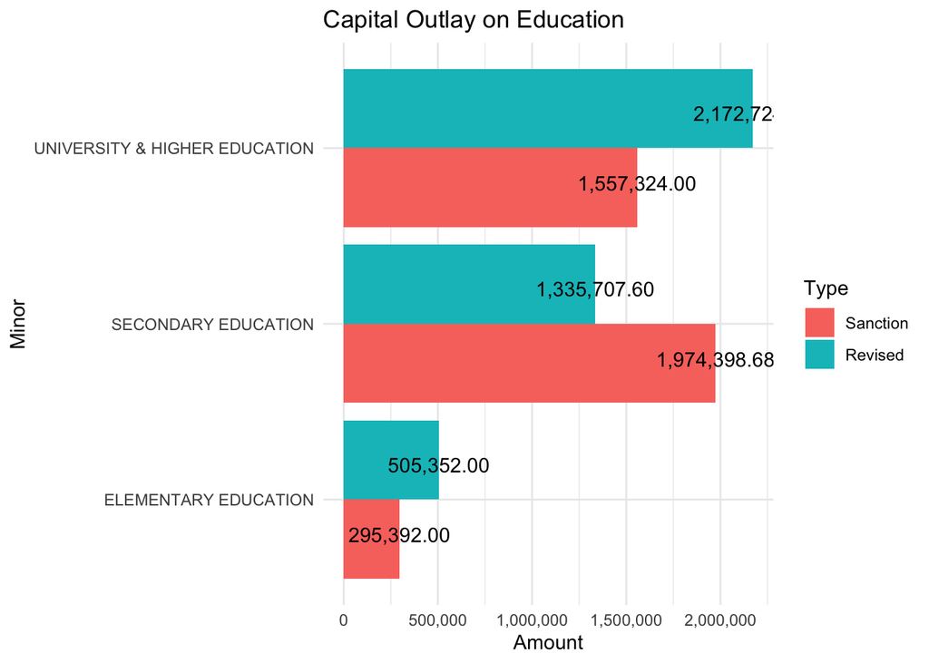

```r
# Capital Outlay
budget_exp_final %>%
    filter(demand_desc == "EDUCATION" & year == "2018-19" &
             major_desc == "CAPITAL OUTLAY  ON EDUCATION S") %>%
    group_by(minor_desc) %>%
    summarise(sanction = sum(sanction), revised = sum(revised)) %>%
    gather(type, amount, -minor_desc) %>%
    mutate(type = as_factor(type)) %>%
    ggplot(aes(x = minor_desc, y = amount, fill = type, label = amount)) +
        geom_bar(stat = "identity", position = "dodge") +
        scale_y_continuous(labels = comma) + geom_text(position = position_dodge(width = 0.8)) +
        scale_fill_discrete(name = "Type", labels = c("Sanction", "Revised")) +
        labs(title = "Capital Outlay on Education", x = "Minor", y = "Amount") +
        theme_minimal() + coord_flip()
```

```r
# SOE
capital_outlay_ed <- budget_exp_final %>%
    filter(demand_desc == "EDUCATION" & year == "2018-19" &
             major_desc == "CAPITAL OUTLAY  ON EDUCATION S") %>%
    group_by(soe_description) %>%
    summarise(sanction = sum(sanction), revised = sum(revised))

# Rename fields
names(capital_outlay_ed) <- c("SOE", "Sanction", "Revised")

# Print formatted table
formattable(capital_outlay_ed,
            list(
              Sanction = color_tile("coral", "tomato"),
              Revised = color_tile("lightgreen", "seagreen")
            )
)
```

| SOE | Sanction | Revised |
| --- | --- | --- |
| MACHINERY AND EQUIPMENT | 27,559.06 | 27,559.06 |
| MAJOR WORKS | 3,799,555.62 | 3,986,224.54 |

- Capital Outlay on Education was highest for University and Higher Education (54%) and lowest for Elelmentary Education (13%)
- Over 99% of all Capital Outlay state expenditure was towards Major Works statement of expenditure.

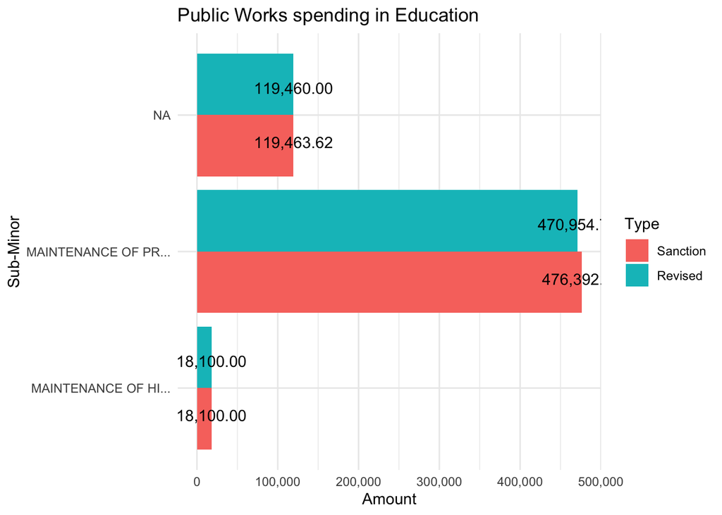

```r
# Public Works
budget_exp_final %>%
    filter(demand_desc == "EDUCATION" & year == "2018-19" &
             major_desc == "PUBLIC WORKS") %>%
    group_by(sub_minor_desc) %>%
    summarise(sanction = sum(sanction), revised = sum(revised)) %>%
    gather(type, amount, -sub_minor_desc) %>%
    mutate(type = as_factor(type)) %>%
    ggplot(aes(x = sub_minor_desc, y = amount, fill = type, label = amount)) +
        geom_bar(stat = "identity", position = "dodge") +
        scale_x_discrete(label = function(x) stringr::str_trunc(x, 20)) +
        scale_y_continuous(labels = comma) +
        geom_text(position = position_dodge(width = 0.8)) +
        scale_fill_discrete(name = "Type", labels = c("Sanction", "Revised")) +
        labs(title = "Public Works spending in Education", x = "Sub-Minor", y = "Amount") +
        theme_minimal() + coord_flip()
```

- The state expenditure under the Major Public Works, over 77% was towards - MAINTENANCE OF PRIMARY SCHOOL BUILDINGS. [S00N].

### **Additional Ideas**

#### **General Education**

Observation of various Minor account heads under General Education to understand trends.

```r
# Minor
gen_ed_minor <- budget_exp_final %>%
    filter(demand_desc == "EDUCATION" & year == "2018-19" &
             major_desc == "GENERAL EDUCATION") %>%
    group_by(minor_desc) %>%
    summarise(sanction = sum(sanction), revised = sum(revised)) %>%
    mutate(percent = formattable::percent(revised - sanction)/sanction) %>%
    arrange(desc(revised))

# Rename fields
names(gen_ed_minor) <- c("Minor", "Sanction", "Revised", "Percent")

# Print formatted table
formattable(gen_ed_minor, list(
                            Sanction = color_tile("coral", "tomato"),
                            Revised = color_tile("lightgreen", "seagreen"),
                            Percent = color_tile("paleturquoise", "turquoise")
                            )
            )
```

| Minor | Sanction | Revised | Percent |
| --- | --- | --- | --- |
| GOVERNMENT PRIMARY SCHOOLS | 101,435,998.28 | 83,862,100.12 | -17.33% |
| GOVERNMENT SECONDARY SCHOOLS | 83,553,998.30 | 70,188,755.58 | -16.00% |
| GOVERNMENT COLLEGES & INSTITUTES | 12,604,231.84 | 10,730,284.54 | -14.87% |
| SARAV SHIKSHA ABHYAN | 9,529,288.00 | 7,862,589.32 | -17.49% |
| OTHER EXPENDITURE | 4,097,760.36 | 4,155,195.28 | 1.40% |
| ASSISTANCE TO UNIVERSITIES | 2,744,322.00 | 3,106,322.00 | 13.19% |
| INSPECTION | 3,132,842.12 | 2,969,529.44 | -5.21% |
| TEACHERS TRAINING | 574,856.00 | 633,355.20 | 10.18% |
| SCHOLARSHIPS | 417,027.62 | 624,920.60 | 49.85% |
| DIRECTION AND ADMINISTRATION | 1,153,002.58 | 619,208.24 | -46.30% |
| ASSISTANCE TO NON GOVERNMENT COLLEGES & INSTITUTES. | 617,572.00 | 614,773.74 | -0.45% |
| DIRECTION & ADMINISTRATION | 673,616.84 | 564,151.66 | -16.25% |
| SANSKRIT EDUCATION | 238,007.76 | 214,637.04 | -9.82% |
| ASSISTANCE TO NON GOVERNMENT SECONDARY SCHOOLS | 3.62 | 37,376.50 | 1032400.00% |
| ASSISTANCE TO NON-GOVERNMENT PRIMARY SCHOOLS | 72,403.62 | 4,796.50 | -93.38% |
| RESEARCH | 2,534.00 | 2,899.62 | 14.43% |
| RURAL FUNCTIONAL LITERACY PROGRAMMES | 724.00 | 0.00 | -100.00% |

**Further Questions**

- Teacher Training as a share of Education under different levels.
- Composition of spending under Sarav Sikhsha Abhyan.
- Spending on assistance to non govt. educational organisations.

#### **Education Account Heads**

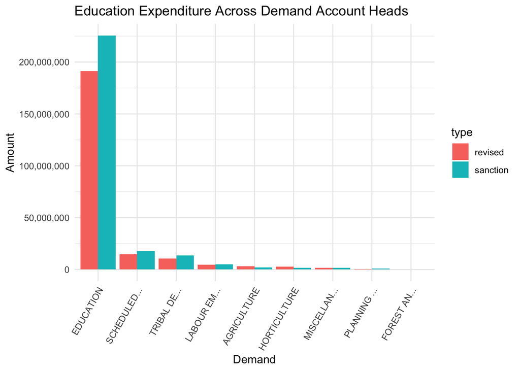

```r
# Education Spending
budget_exp_final %>%
    filter(year == "2018-19") %>%
    filter(stringr::str_detect(demand_desc, pattern = "EDUC") |
           stringr::str_detect(major_desc, pattern = "EDUC")) %>%
    group_by(demand_desc) %>%
    summarise(sanction = sum(sanction), revised = sum(revised)) %>%
    arrange(desc(sanction)) %>%
    gather(type, amount, -demand_desc) %>%
    mutate(demand_desc = as_factor(demand_desc)) %>%
    ggplot(aes(x = demand_desc, y = amount, fill = type)) +
        geom_bar(stat = "identity", position = position_dodge()) +
        scale_x_discrete(label = function(x) stringr::str_trunc(x, 12)) +
        scale_y_continuous(labels = comma) +
        labs(title = "Education Expenditure Across Demand Account Heads", x = "Demand", y = "Amount") +
        theme_minimal() + theme(axis.text.x = element_text(angle = 60, vjust = 1, hjust = 1))
```

Education specific account heads are across all demand heads.

**General Education Across Demand Account Heads**

```r
# Education Spending
gen_education_across <- budget_exp_final %>%
    filter(year == "2018-19" & major_desc == "GENERAL EDUCATION") %>%
    group_by(demand_desc) %>%
    summarise(sanction = sum(sanction), revised = sum(revised)) %>%
    mutate(percent = (revised - sanction)/sanction) %>%
    arrange(desc(revised))

# Format % Field
gen_education_across$percent <- formattable::percent(gen_education_across$percent)

# Rename Fields
names(gen_education_across) <- c("Demand", "Sanction", "Revised", "Percent")

# Print formatted table
formattable(gen_education_across,
            list(
              Sanction = color_tile("coral", "tomato"),
              Revised = color_tile("lightgreen", "seagreen"),
              Percent = color_tile("paleturquoise", "turquoise")
              )
)
```

| Demand | Sanction | Revised | Percent |
| --- | --- | --- | --- |
| EDUCATION | 220,848,188.94 | 186,190,895.38 | -15.69% |
| SCHEDULED CASTES SUB PLAN | 14,329,770.00 | 10,883,815.98 | -24.05% |
| TRIBAL DEVELOPMENT | 12,327,283.74 | 8,670,909.98 | -29.66% |
| PLANNING AND BACKWARD AREA SUB-PLAN | 676,599.72 | 158,429.30 | -76.58% |
| MISCELLANEOUS GENERAL SERVICES | 176,471.38 | 137,588.96 | -22.03% |

- General Education expenditure is spread across various account heads, requireing further exploration.
- There is decreased is revised state budget expenditure across the different demand account heads.

#### **Major Account Heads Codes**

| Begins with | Accounts |
| --- | --- |
| 20 | Administration |
| 24/25/27 | Agricultural/Rural |
| 30 | Transportation/Tourism |
| 4 | Capital Outlay |
| 5 | Capital Outlay towards Transporation/Tourism |
| 6 | Debts and Loans |
| 7 | Loans to Govt. Servants |